# Diagnostics for the Logistic Beta TLSF kernel

Michael Gordy

2023-08-16

```r
#knitr::opts_chunk$set(echo = FALSE)
knitr::opts_chunk$set(fig.width = 9.5)


library(ggplot2)
library(spectralBacktest)
library(purrr)
library(dplyr)
library(tidyr)
source("helperFiles/DefineKernels.R")

support<- c(0.95,1)

tlsfsig <- function(tlsfkernel, PIT) {
  W_list <- tlsfkernel$nu(tlsfkernel$support, tlsfkernel$param)(PIT)
  Wbar <- purrr::list_transpose(W_list, simplify=TRUE)
  Sigma<-tlsfkernel$VCV(tlsfkernel$support, tlsfkernel$param)
  purrr::map_dbl(Wbar, ~sqrt(mahalanobis(.x, center=0, cov=Sigma)))
}
PIT <- 1-10^seq(log10(1-1.0001*support[1]),log10(1-0.99999999*support[2]),length.out=250)
kern_vec2 <- c("PNS","LLS", "GS","GcS", "LB1", "LB1c", "LB2", "LB2c", "LB3", "LB3c",
               "LLtest", "LBtest", "LBtestc", "LBtest1","LBtest2","LBup","LBdown")
kernel_list <- define_kernels_tlsf(support[1], support[2])[kern_vec2]
kernnames <- data.frame(mnemonic=kern_vec2) |>
  mutate(kernel=purrr::map_chr(mnemonic, ~kernel_list[[.x]]$name))
df <- purrr::map_dfc(kernel_list, ~tlsfsig(.x,PIT)) |>
  mutate(PIT=PIT) |>
  tidyr::pivot_longer(cols=-PIT, names_to = "mnemonic", values_to = "value") |>
  dplyr::left_join(kernnames, by="mnemonic")

subsetplot <- function(df, kmnem) {
  df1 <- df |> filter(mnemonic %in% kmnem)
  p <- ggplot(df1, aes(x=1-PIT, y=value, color=kernel, group=kernel)) +
    geom_line() +
    scale_y_log10() + scale_x_log10() +
    labs(x="1-PIT (log scale)",y="Mahalanobis distance (log scale)")
  return(p)
}
```

In this notebook we visualize the Logistic Beta kernel to check whether “nearby” kernels behave similarly. Specifically, we plot the Mahalanobis distance
$$M_\nu(\alpha) =
\sqrt{\nu(\alpha)\Sigma_\nu^{-1}\nu(\alpha)^\prime}$$
as a function of $\alpha$ where the bivariate kernel $\nu$ is centered but not scaled to unit variance. In each exercise below, we compare the logit-logistic score kernel against alternatives. We fix a kernel window of $[0.95,1]$ throughout.

First we compare against the benchmark TLSF kernels include as Examples in the paper. It is interesting that the `Gumbel` is almost indistinguishable from the `Logit-Logistic Score` (LLS), even though the Gumbel has positive skewness (1.14) and higher kurtosis (5.4 for Gumbel vs 4.2 for LLS).

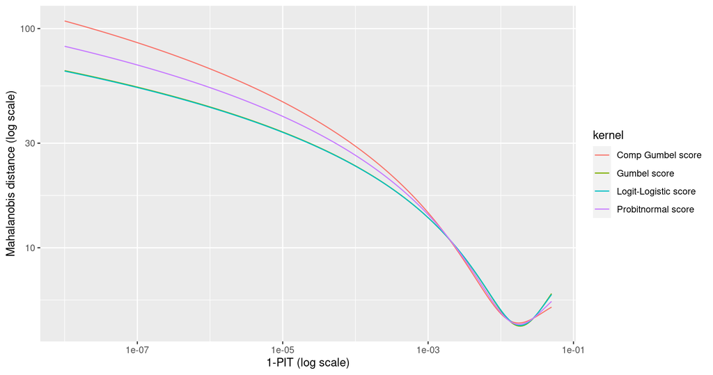

```r
subsetplot(df, c("LLS", "PNS", "GS", "GcS"))
```

For the Logistic Beta family, it is straightforward to calculate skewness and kurtosis for the untruncated distribution (i.e., assuming a support of the unit interval). The following table confirms that distributions with nearby parameters have nearby higher moments and that complementary distributions differ only in the sign of skewness. Whether these properties of the untruncated distributions are reliable guides to the behavior of the corresponding score kernels is an open question.

```r
LBkernels <- data.frame(mnemonic=kern_vec2) |>
  filter(!(mnemonic %in% c("PNS", "GS", "GcS", "LLS"))) |>
  mutate(a=purrr::map_dbl(mnemonic, ~kernel_list[[.x]]$param[1]),
         b=purrr::map_dbl(mnemonic, ~kernel_list[[.x]]$param[2]),
         skewness=purrr::map_dbl(mnemonic,~cumulants_logisticbeta(kernel_list[[.x]]$param)$skewness),
         kurtosis=purrr::map_dbl(mnemonic,~cumulants_logisticbeta(kernel_list[[.x]]$param)$kurtosis)) |>
  select(-mnemonic) |> arrange(kurtosis, skewness)

knitr::kable(LBkernels, caption="Higher moments of the Logistic Beta(a,b) distribution")
```

Higher moments of the Logistic Beta(a,b) distribution

| a | b | skewness | kurtosis |
| --- | --- | --- | --- |
| 1.5000000 | 1.5000000 | 0.0000000 | 3.806250 |
| 1.0200000 | 1.0200000 | 0.0000000 | 4.178492 |
| 1.0000000 | 1.0000000 | 0.0000000 | 4.200000 |
| 0.9800000 | 1.0200000 | -0.0435342 | 4.202617 |
| 1.0200000 | 0.9800000 | 0.0435342 | 4.202617 |
| 0.9800000 | 0.9800000 | 0.0000000 | 4.222140 |
| 0.5000000 | 0.5000000 | 0.0000000 | 5.000000 |
| 0.5000000 | 1.0000000 | -0.8546603 | 5.400000 |
| 1.0000000 | 0.5000000 | 0.8546603 | 5.400000 |
| 0.5000000 | 1.5000000 | -1.1251404 | 5.868265 |
| 1.5000000 | 0.5000000 | 1.1251404 | 5.868265 |
| 0.3333333 | 0.6666667 | -1.0000000 | 6.000000 |
| 0.6666667 | 0.3333333 | 1.0000000 | 6.000000 |

In the next plot, we verify that `Logistic Beta(0.98,0.98)` and `Logistic Beta(1.02,1.02)` both closely approximate the `Logit-Logistic Score`. We have confirmed (not shown) that the `Logistic Beta(1,1)` matches `LLS` exactly.

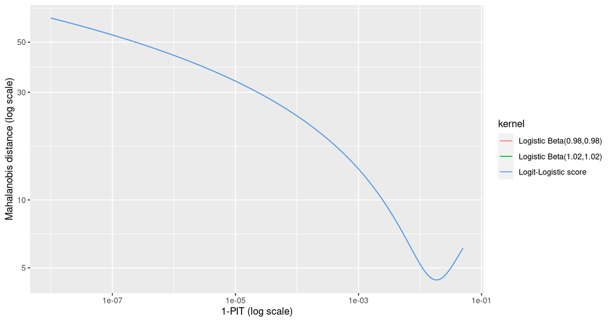

```r
subsetplot(df, c("LLS", "LBtest1", "LBtest2"))
```

We compare the `Logit-Logistic Score` against two other symmetric Logistic Beta distributions.

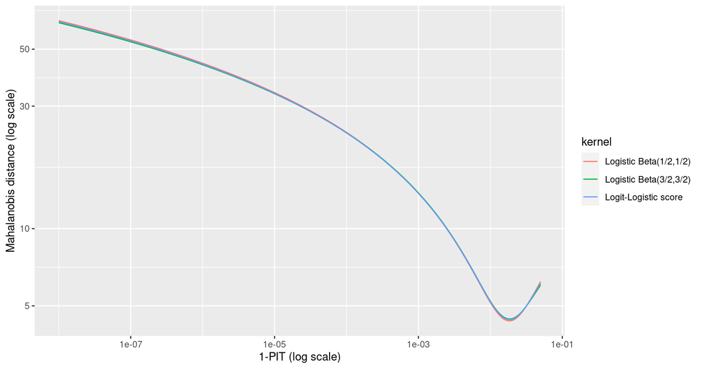

```r
subsetplot(df, c("LLS", "LBup", "LBdown"))
```

The final three plots consider representative complementary pairs of Logistic Beta kernels.

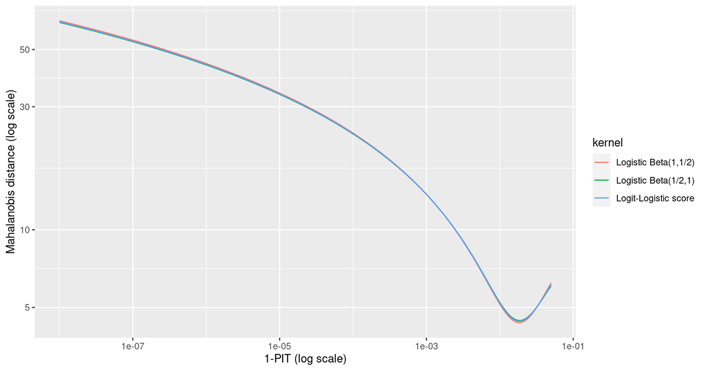

```r
subsetplot(df, c("LLS", "LB1", "LB1c"))
```

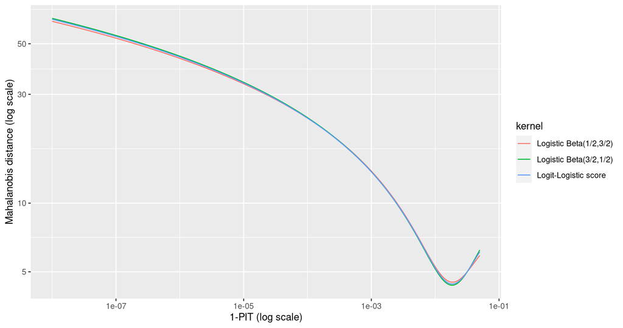

```r
subsetplot(df, c("LLS", "LB2", "LB2c"))
```

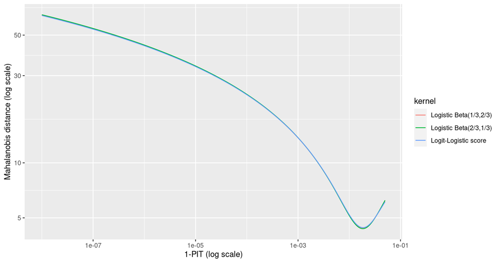

```r
subsetplot(df, c("LLS", "LB3", "LB3c"))
```